# MAD – Data Analysis & Biostatistics in R

16 October 2020

[figure not shown]

## Introduction

## Program for Today

- Change in plan
- You’ve been finding recent weeks difficult
  - Too many concepts that are too abstract
  - Manipulating them in homework not too difficult
- Let’s go back to inference and cover
  - p-values and confidence intervals
  - What regression is, how it works
    - What inferences can be drawn from it
  - Regression: statistics approach vs machine learning approach
- Workflow for using these tools

## Perspective of the “ModernDive” Team

[figure not shown]

- Book:
  - Chester Ismay and Albert Y. Kim, **Statistical Inference via Data Science: A ModernDive into R and the Tidyverse**, https://moderndive.com/index.html (new version July 2020)
- Packages: `moderndive` and `infer`
  - not in original set of downloads
  - install with ´install.package(“moderndive”, “infer”)`
- Simulation (i.e., non-theoretical) approach to inference

## The Bowl of Red and White Balls–Simple Proportions

## The Bowl

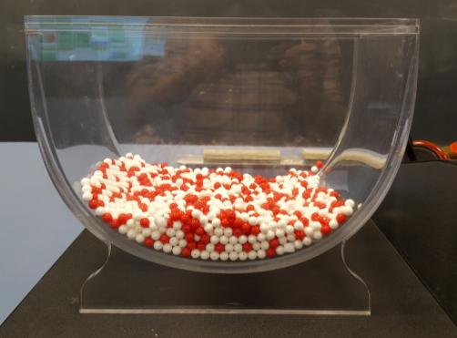

- Bowl has 2,400 well-mixed red and white balls
- What proportion are red?
- We could take census–count all the balls
  - Long, boring
  - Doesn’t teach sampling

```r
bowl <- moderndive::bowl
bowl
```

```
## # A tibble: 2,400 x 2
##    ball_ID color
##      <int> <chr>
##  1       1 white
##  2       2 white
##  3       3 white
##  4       4 red
##  5       5 white
##  6       6 white
##  7       7 red
##  8       8 white
##  9       9 red
## 10      10 white
## # ... with 2,390 more rows
```

## Take Virtual Sample of 50 Balls

- We will take a random sample of 50 balls
  - Count the number of red balls
  - Divide by 50

## Taking a Virtual Sample in Virtual 2020

- function `infer::rep_sample_n()`
  - Take random samples of certain size from a data frame
    - `tbl`: name of data frame/tibble
    - `size`: number of cases in sample
    - `reps`: number of samples/replicates
    - `replace =`: whether to sample with or without replacement

```r
set.seed(42)
s1 <- rep_sample_n(bowl, size = 50, reps = 1)
head(s1, 10)
```

```
## # A tibble: 10 x 3
## # Groups:   replicate [1]
##    replicate ball_ID color
##        <int>   <int> <chr>
##  1         1    2369 red
##  2         1    1177 red
##  3         1    1098 red
##  4         1    1252 red
##  5         1     634 white
##  6         1    2097 red
##  7         1    1152 white
##  8         1    1327 red
##  9         1    2072 white
## 10         1     356 red
```

## Proportion of Red Balls in Sample 1

- Create a logical variable `is_red`
- Sum the number of TRUE’s (i.e., reds)
- Divide by 50

```r
s1 %>%
  mutate(is_red = (color == "red")) %>%
  summarise(num_red = sum(is_red),
            prop_red = num_red/50)
```

```
## # A tibble: 1 x 3
##   replicate num_red prop_red
##       <int>   <int>    <dbl>
## 1         1      25      0.5
```

## Will a 2nd Sample Have Same Proportion? Let’s Try It

```r
s2 <- rep_sample_n(bowl, size = 50, reps = 1)
s2 %>%
  mutate(is_red = (color == "red")) %>%
  summarise(num_red = sum(is_red),
            prop_red = num_red/50)
```

```
## # A tibble: 1 x 3
##   replicate num_red prop_red
##       <int>   <int>    <dbl>
## 1         1      20      0.4
```

Nope

## Let’s Try to Get a Sample for Each Student in the Class

- We have approx. 20 survivors students in the class
- Let’s take 20 samples and see the distribution of the proportions

## Head Student Samples

```r
student_samples <- rep_sample_n(bowl, size = 50, reps = 20)
student_samples
```

```
## # A tibble: 1,000 x 3
## # Groups:   replicate [20]
##    replicate ball_ID color
##        <int>   <int> <chr>
##  1         1    1693 white
##  2         1      25 red
##  3         1    1907 white
##  4         1     703 white
##  5         1     623 white
##  6         1    2310 red
##  7         1     943 white
##  8         1     299 red
##  9         1     754 red
## 10         1     799 white
## # ... with 990 more rows
```

## Tail Student Samples

```r
tail(student_samples, 10)
```

```
## # A tibble: 10 x 3
## # Groups:   replicate [1]
##    replicate ball_ID color
##        <int>   <int> <chr>
##  1        20    1767 red
##  2        20    1060 white
##  3        20    1935 white
##  4        20    1338 red
##  5        20     285 red
##  6        20     719 white
##  7        20    1758 white
##  8        20     464 white
##  9        20    2029 white
## 10        20    1425 red
```

## Calculate the Proportion of Reds for All 20 Samples

```r
student_samp_results <- student_samples %>%
  group_by(replicate) %>%
  summarize(red = sum(color == "red")) %>%
  mutate(prop_red = red / 50)
```

```r
head(student_samp_results, 10)
```

```
## # A tibble: 10 x 3
##    replicate   red prop_red
##        <int> <int>    <dbl>
##  1         1    20     0.4
##  2         2    10     0.2
##  3         3    20     0.4
##  4         4    20     0.4
##  5         5    21     0.42
##  6         6    23     0.46
##  7         7    17     0.34
##  8         8    23     0.46
##  9         9    20     0.4
## 10        10    17     0.34
```

## Histogram of Students’ Samples

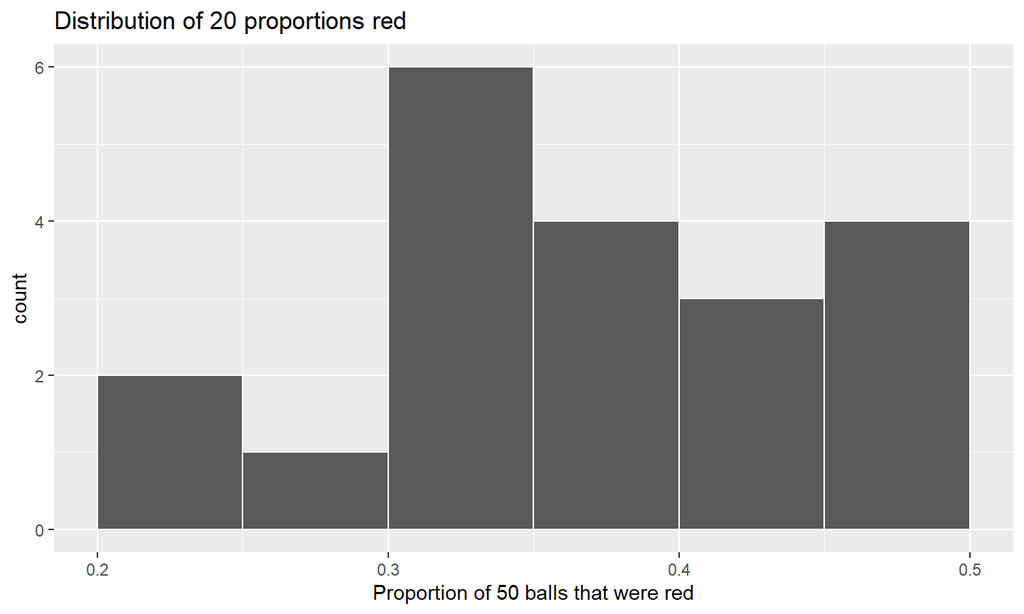

```r
gg_stud_samp <- ggplot(student_samp_results, aes(x = prop_red)) +
  geom_histogram(binwidth = 0.05, boundary = 0.4, color = "white") +
  labs(x = "Proportion of 50 balls that were red",
       title = "Distribution of 20 proportions red")
```

## Let’s Try 1,000 Samples

```r
mil_samples <- rep_sample_n(bowl, size = 50, reps = 1000)
mil_samples
```

```
## # A tibble: 50,000 x 3
## # Groups:   replicate [1,000]
##    replicate ball_ID color
##        <int>   <int> <chr>
##  1         1    1775 white
##  2         1     577 white
##  3         1    1082 red
##  4         1    1847 white
##  5         1     328 white
##  6         1     560 white
##  7         1    1390 red
##  8         1     203 red
##  9         1    1071 red
## 10         1      92 white
## # ... with 49,990 more rows
```

## Calculate Proportion of Reds 1,000 Samples

```r
mil_samp_results <- mil_samples %>%
  group_by(replicate) %>%
  summarize(red = sum(color == "red")) %>%
  mutate(prop_red = red / 50)
```

```
## # A tibble: 1,000 x 3
##    replicate   red prop_red
##        <int> <int>    <dbl>
##  1         1    20     0.4
##  2         2    21     0.42
##  3         3    19     0.38
##  4         4    12     0.24
##  5         5    18     0.36
##  6         6    19     0.38
##  7         7    16     0.32
##  8         8    15     0.3
##  9         9    18     0.36
## 10        10    22     0.44
## # ... with 990 more rows
```

## Histogram of 1,000 Samples

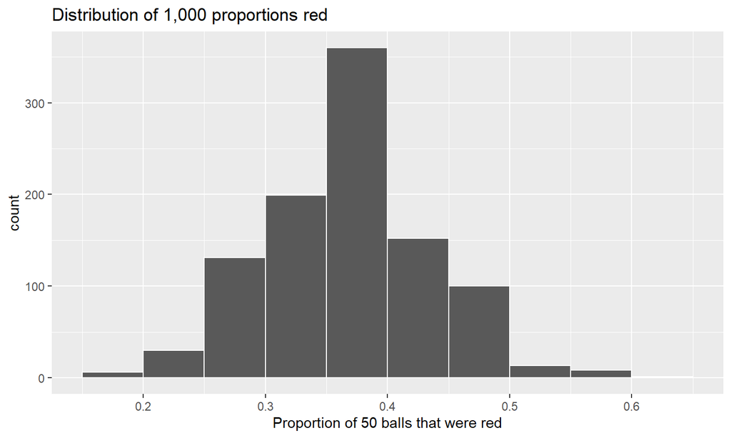

```r
gg_samp_mil <- ggplot(mil_samp_results, aes(x = prop_red)) +
  geom_histogram(binwidth = 0.05, boundary = 0.4, color = "white") +
  labs(x = "Proportion of 50 balls that were red",
       title = "Distribution of 1,000 proportions red")
```

## Histogram of 1,000 Samples

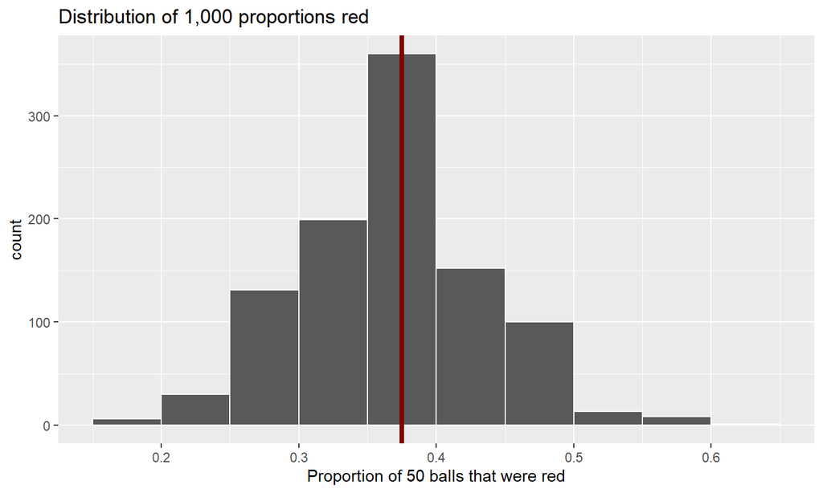

## What is Impact of Increasing Sample Size

- Try sample size of 100 instead of 50
  - Remain with 1,000 samples

```r
sample_100 <- rep_sample_n(bowl, size = 100, reps = 1000)
```

```
## # A tibble: 100,000 x 3
## # Groups:   replicate [1,000]
##    replicate ball_ID color
##        <int>   <int> <chr>
##  1         1     667 white
##  2         1     282 white
##  3         1      95 white
##  4         1    1549 white
##  5         1     453 white
##  6         1     986 red
##  7         1     224 white
##  8         1    1306 white
##  9         1    1203 red
## 10         1    2317 white
## # ... with 99,990 more rows
```

## Calculate Proportion of Reds Sample of 100

```r
samp_100_results <- sample_100 %>%
  group_by(replicate) %>%
  summarize(red = sum(color == "red")) %>%
  mutate(prop_red = red / 100)
```

```
## # A tibble: 1,000 x 3
##    replicate   red prop_red
##        <int> <int>    <dbl>
##  1         1    37     0.37
##  2         2    37     0.37
##  3         3    41     0.41
##  4         4    44     0.44
##  5         5    37     0.37
##  6         6    46     0.46
##  7         7    36     0.36
##  8         8    36     0.36
##  9         9    37     0.37
## 10        10    36     0.36
## # ... with 990 more rows
```

## Histogram of Sample of 100

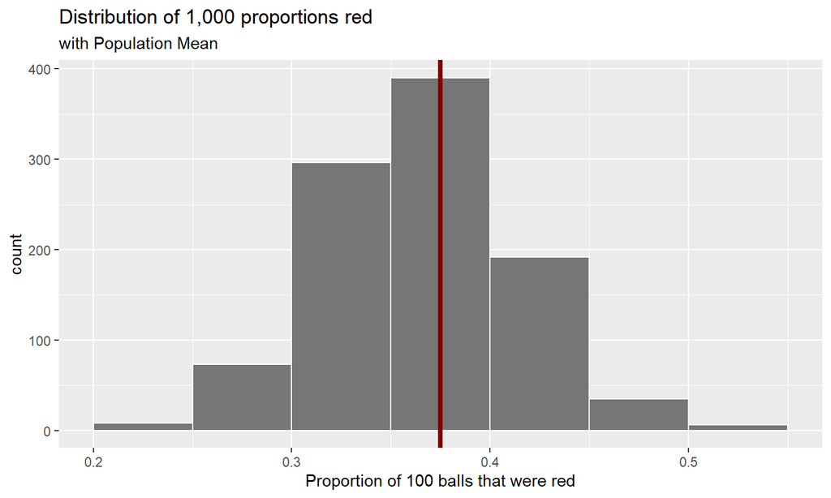

## How Much Variance in Each of These Results?

| sample | sample_size | samples | mean_prop | standard_dev |
| --- | --- | --- | --- | --- |
| Student Sample | 50 | 20 | 0.371000 | 0.0741194 |
| 1,000 Samples | 50 | 1000 | 0.372580 | 0.0673103 |
| Samples with 100 | 100 | 1000 | 0.371150 | 0.0478693 |
| Samples with 500 | 500 | 1000 | 0.374938 | 0.0184252 |

## Implication for Inference

- **If** sampling of balls **random**, what we take out is an **unbiased representation** of the population
- \(\therefore\), any result based on the sample can be **generalized** to the population
- \(\therefore\), a **sample statistic** is a *good guess* of unknown **population parameter**
- \(\therefore\), we don’t need to perform a census: can **infer** population value from sample

## Definition of Inference

> theory, methods, and practice of forming judgments about the parameters of a population and the reliability of statistical relationships, typically on the basis of random sampling
> - From ModernDive

## Bootstrap Sampling

## Bootstrap Sampling

- What happens when you only have a single sample to work with?
- How can you study effects of sampling variation?
- Basic idea: resampling the sample **with replacement**
- Resampling mimics the sampling variation across variety of samples
  - Approximates sampling distribution of the mean/proportion as in first example
- To do bootstrap resampling,
  - Add argument to `rep_sample_n()`: `replace = TRUE`
- Analog to biological amplification techniques

## Basic Process of Bootstrap Resampling

- Draw a sample of n balls from the bowl
  - Put them in a separate bowl
- Resample
  - Take 1 ball out of the **new** bowl
  - Record its color
  - **Return it to the new bowl** (“with replacement”)
  - Repeat previous 3 steps until you have complete resample
- Repeat process for all resamples you want to take
- You may draw the same ball more than once
- Some balls will never be drawn in a given resample
- Each resample is different

## Data for Bootstrap – Systolic Blood Pressure in Altibaixo, SP

- City of Altibaixo, SP
  - Pop 64,347
- Blood pressure file: `altibaixo_sbp.rds`
- Only have funds to sample 200 Altibaixianos

```r
alti_baix <- readRDS(here("altibaixo_sbp.rds"))
set.seed(42)
sbp_samp <- alti_baix %>%
  rep_sample_n(size = 200, replace = FALSE)
sbp_samp$replicate <- NULL
```

## Altibaixo Blood Pressure Sample

```r
sbp_samp
```

```
## # A tibble: 200 x 2
##       id   sbp
##    <int> <dbl>
##  1 61413   143
##  2 54425   150
##  3 34020   117
##  4  8826   149
##  5 46208   144
##  6 47128   111
##  7 16740   140
##  8 61605   141
##  9  7700   121
## 10 36722   102
## # ... with 190 more rows
```

## Making Bootstrap Resamples

- Colored balls: Went back to the jar and took brand new samples
- With the bp’s, can’t do that
- Take our sample and resample from it
- From sample of 200, we will take new sample of 200 with replacement
- We will take 50 of these new resamples

```r
resamples <- sbp_samp %>%
  rep_sample_n(size = 200, replace = TRUE, reps = 50)
```

## Find the Mean SBP of Each Resample

```r
resample_means <- resamples %>%
  group_by(replicate) %>%
  summarise(mean_sbp = mean(sbp),
            .groups = "drop")
```

```
## # A tibble: 50 x 2
##    replicate mean_sbp
##        <int>    <dbl>
##  1         1     129.
##  2         2     123.
##  3         3     129.
##  4         4     124.
##  5         5     127.
##  6         6     128.
##  7         7     130.
##  8         8     129.
##  9         9     131.
## 10        10     131.
## # ... with 40 more rows
```

## Histogram of Resampled Means

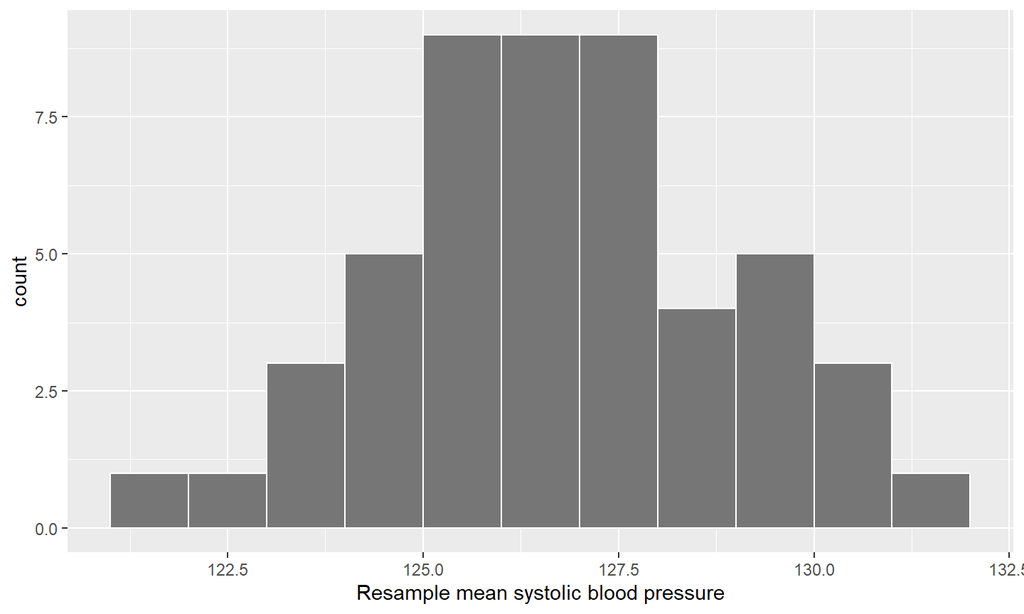

## Now Try the Resampling 1,000 Times

```r
resamp_mil_means <- sbp_samp %>%
  rep_sample_n(size = 200, replace = TRUE, reps = 1000) %>%
  group_by(replicate) %>%
  summarise(mean_sbp = mean(sbp), .groups = "drop")
```

```
## # A tibble: 1,000 x 2
##    replicate mean_sbp
##        <int>    <dbl>
##  1         1     128.
##  2         2     127.
##  3         3     126.
##  4         4     126.
##  5         5     128.
##  6         6     127.
##  7         7     126.
##  8         8     128.
##  9         9     127.
## 10        10     126.
## # ... with 990 more rows
```

## Histogram of 1,000 Resampled Means

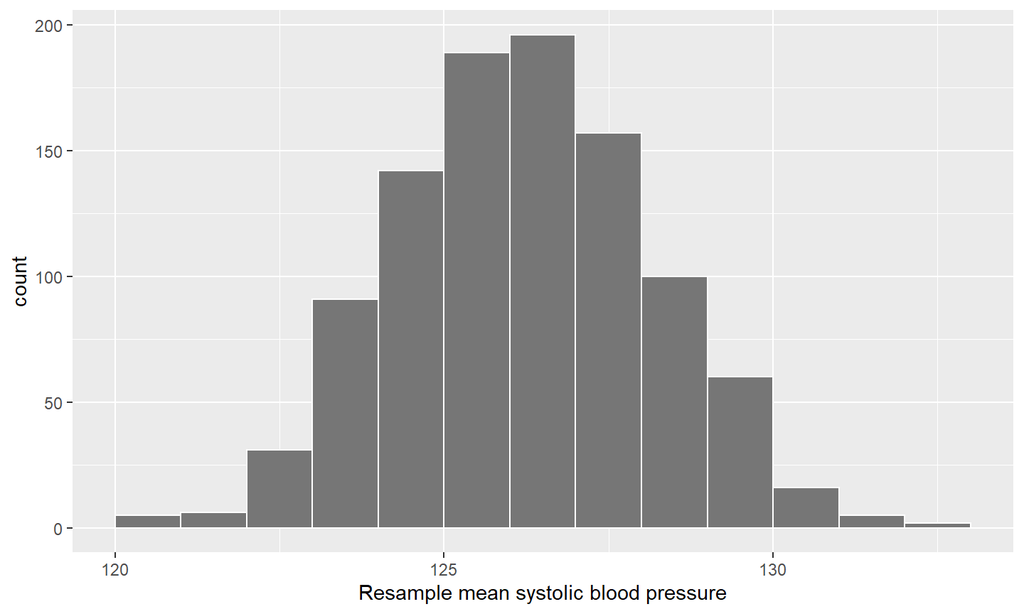

## Means & Standard Deviations

- Calculate the Means and Standard Deviations of the original 50 resamples and the 1,000 resamples

| resample | mean_sbp | standard_dev |
| --- | --- | --- |
| 50 Resamples | 126.7246 | 2.231210 |
| 1,000 Resamples | 126.2256 | 1.950253 |

- Mean of Altibaixo sbp: 128.045
- Mean of original sample: 126.285
- Remember here that you are **re**sampling the original sample
- Frequently reflects what really happens in practical research

## Confidence Intervals

## Confidence Intervals and Hypothesis Tests

- **Hypothesis tests**: Trying to ascertain if a point estimate is accurate
  - Test statistic reflects the population parameter
- **Confidence Interval**: what are some reasonable values of test statistic to consider when thinking about where the population parameter lies

## Confidence Interval Meme

[figure not shown]

## Determine Confidence Intervals – 2 Methods

- Standard Error/Margin of Error
  - We looked at this
  - Will look at it again
- Percentile method (for a 95% Confidence Interval)
  - Use the middle 95% of values of bootstrap distribution
  - Remember: Confidence Intervals determine values based on samples
  - Leave out 2.5% at both ends of the distribution
  - 2.5th and 97.5th percentiles: what is between them potentially contains population mean

## `infer` Package Confidence Interval Workflow

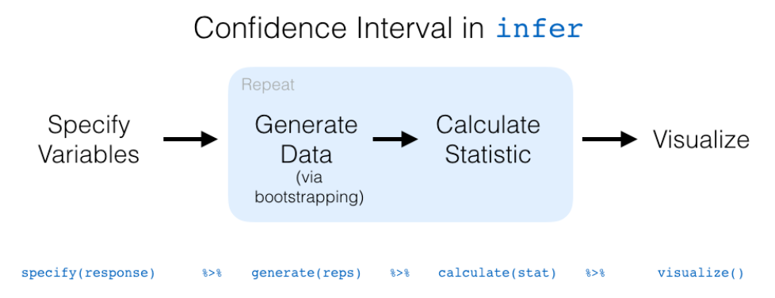

## `specify()` – Choose Variables

- Just a response variable (variable of interest): argument `response =`
- If also independent (explanatory) variables
  - Formula format: `response ~ explanatory`
    - Similar to regression
    - `sbp_samp`: `sbp ~ NULL` (no explanatory variable)
  - Arguments: `response =` and `explanatory =`
- Similar to `dplyr::group_by()`

## Example

```r
sbp_samp %>%  # original sample used for bootstrap resampling
  specify(response = sbp) # variable we want to measure
```

```
## Response: sbp (numeric)
## # A tibble: 200 x 1
##      sbp
##    <dbl>
##  1   143
##  2   150
##  3   117
##  4   149
##  5   144
##  6   111
##  7   140
##  8   141
##  9   121
## 10   102
## # ... with 190 more rows
```

## `generate()` – Create Replicates

- Create the number of replicates you want
  - `generate(reps = 1000, type = “bootstrap”)
- Similar to `rep_sample_n()`

```
## Response: sbp (numeric)
## # A tibble: 200,000 x 2
## # Groups:   replicate [1,000]
##    replicate   sbp
##        <int> <dbl>
##  1         1   110
##  2         1   157
##  3         1    84
##  4         1    88
##  5         1   102
##  6         1   176
##  7         1   155
##  8         1   149
##  9         1   117
## 10         1   141
## # ... with 199,990 more rows
```

## `calculate()` Summary Statistics

- Calculates a summary statistic you specify with `stat =`
- Where we calculate the bootstrap distribution of the statistic
- Normally has results assigned to a name
- Wide variety of stats available
- Equivalent of `dplyr::summarise()`

## Bootstrap Sample

```
## # A tibble: 1,000 x 2
##    replicate  stat
##        <int> <dbl>
##  1         1  127.
##  2         2  127.
##  3         3  126.
##  4         4  126.
##  5         5  127.
##  6         6  125.
##  7         7  126.
##  8         8  126.
##  9         9  128.
## 10        10  127.
## # ... with 990 more rows
```

## `visualize()` Visualization

- Showing only basic form here

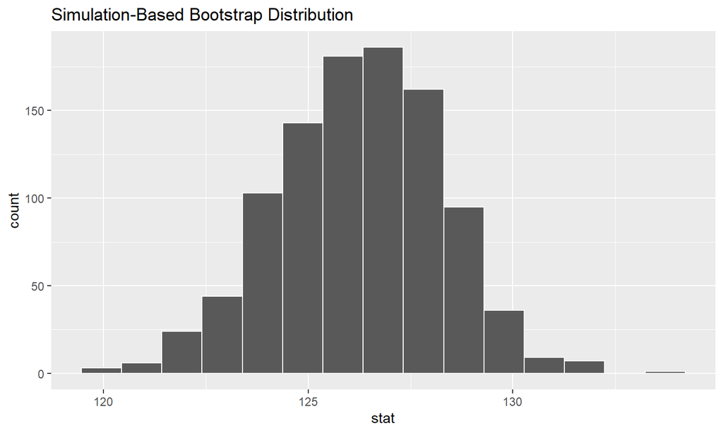

```r
visualize(sbp_bootstrap)
```

## Calculate the Confidence Interval by Percentile

- `get_confidence_interval()`
- Arguments
  - Level: `level =`
  - Type: `type = "percentile"`

```r
percentile_ci <- sbp_bootstrap %>%
  get_confidence_interval(level = 0.95, type = "percentile")
percentile_ci
```

```
## # A tibble: 1 x 2
##   lower_ci upper_ci
##      <dbl>    <dbl>
## 1     122.     130.
```

## Visualize Confidence Interval

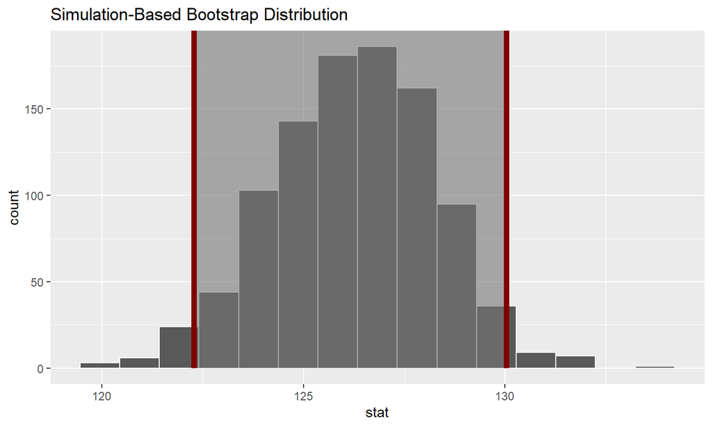

## Did We Hit the Target?

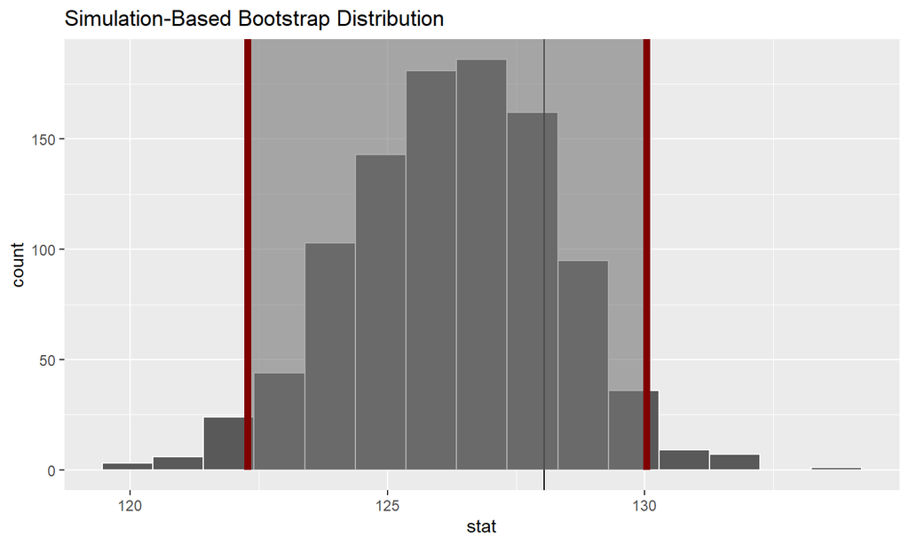

## Test of a Confidence Interval

- Did it contain the population mean?
  - **Yes** Vertical line is in the interval
- Population mean of Altibaixo: 128.0447262
- Mean of original sample: 126.285
- **The net caught the fish**

## Compare to Traditional 1-Sample t-Test

```r
t.test(sbp_samp$sbp)
```

```
##
##  One Sample t-test
##
## data:  sbp_samp$sbp
## t = 63.781, df = 199, p-value < 2.2e-16
## alternative hypothesis: true mean is not equal to 0
## 95 percent confidence interval:
##  122.3806 130.1894
## sample estimates:
## mean of x
##   126.285
```

## Expand to a 2 Variable Problem

- Study to find if male bank employees were promoted at a higher rate than females

```r
promotions <- moderndive::promotions
summarytools::ctable(promotions$decision, promotions$gender, prop = "c")
```

```
## Cross-Tabulation, Column Proportions
## decision * gender
## Data Frame: promotions
##
## ---------- -------- ------------- ------------- -------------
##              gender          male        female         Total
##   decision
##        not             3 ( 12.5%)   10 ( 41.7%)   13 ( 27.1%)
##   promoted            21 ( 87.5%)   14 ( 58.3%)   35 ( 72.9%)
##      Total            24 (100.0%)   24 (100.0%)   48 (100.0%)
## ---------- -------- ------------- ------------- -------------
```

## Null Hypothesis

- \(H_0\): proportion of men promoted equals proportion of women promoted
  - \(H_0: p_m - p_f=0\)
- Add this to the workflow with the `hypothesize()` function
  - `hypothesize(null = "independence")`
- “Independence”: response variable is independent of the explanatory variable

## Set up `infer` Workflow

```r
prom_shuffled <- promotions %>%
  specify(formula = decision ~ gender, success = "promoted") %>%
  hypothesize(null = "independence") %>%
  generate(reps = 1000, type = "permute")
```

- `permute`: alternative to `bootstrap`
- Each input value (gender) gets randomly associated with a new output value (decision) for each replicate
- This is equivalent to testing the data against the **null hypothesis**

## Calculate the Test Statistic

```r
null_dist <- promotions %>%
  specify(formula = decision ~ gender, success = "promoted") %>%
  hypothesize(null = "independence") %>%
  generate(reps = 1000, type = "permute") %>%
  calculate(stat = "diff in props", order = c("male", "female"))
```

```
## # A tibble: 1,000 x 2
##    replicate    stat
##        <int>   <dbl>
##  1         1 -0.125
##  2         2  0.0417
##  3         3 -0.0417
##  4         4 -0.292
##  5         5 -0.125
##  6         6 -0.0417
##  7         7  0.0417
##  8         8 -0.208
##  9         9  0.125
## 10        10 -0.0417
## # ... with 990 more rows
```

## Visualize the Replicates

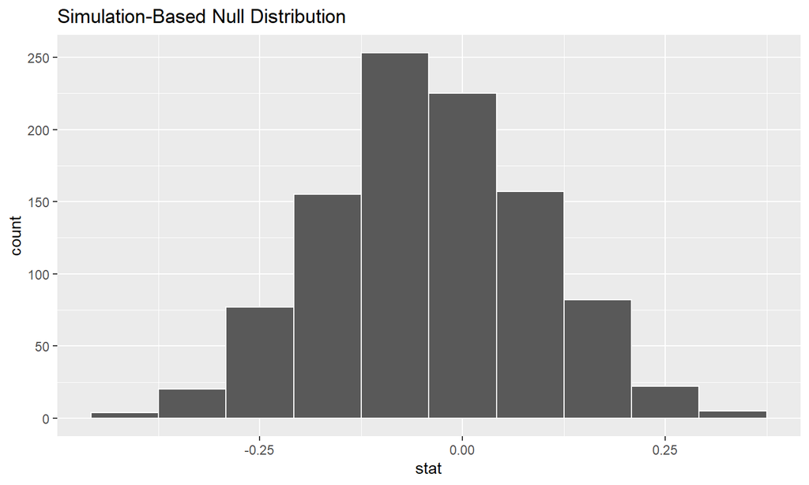

```r
visualize(null_dist, bins = 10)
```

## Calculate the Confidence Interval by Percentile

```r
percentile_ci <- null_dist %>%
  get_confidence_interval(level = 0.95, type = "percentile")
percentile_ci
```

```
## # A tibble: 1 x 2
##   lower_ci upper_ci
##      <dbl>    <dbl>
## 1   -0.208    0.292
```

## What is True Proportion of Excess Males over Females

- 2 methods of calculating
- Traditional
  - 21 of 24 males promoted (0.875 of males)
  - 14 of 24 females promoted (0.583 of females)
  - Difference in promotion rate
    - (0.875 - 0.583) = 0.292
- Is 0.292 a reasonable value given the data we have?

## Using `infer` Workflow

- Same workflow **without** `hypothesize()` and `generate()` steps

```r
obs_diff <- promotions %>%
  specify(decision ~ gender, success = "promoted") %>%
  calculate(stat = "diff in props", order = c("male", "female"))
obs_diff
```

```
## # A tibble: 1 x 1
##    stat
##   <dbl>
## 1 0.292
```

## Histogram with Real Value Added

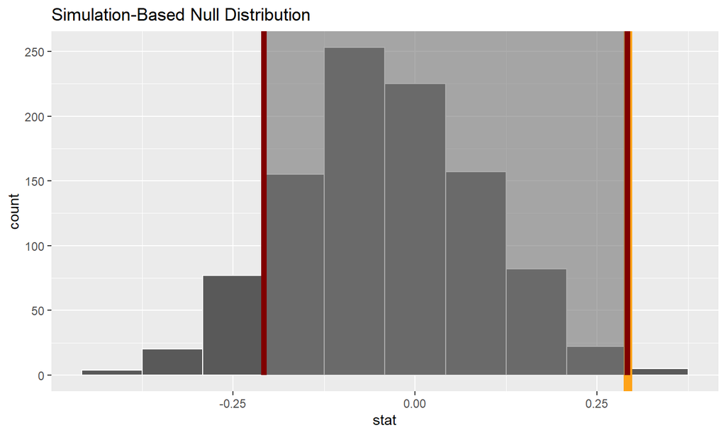

## Promotions Question as a Hypothesis Test

- We have already postulated \(H_0\) and test statistic (\(p_m-p_f\))
- We can calculate p-value with `get_p_value()`

```r
null_dist %>%
  get_p_value(obs_stat = obs_diff, direction = "right")
```

```
## # A tibble: 1 x 1
##   p_value
##     <dbl>
## 1   0.027
```

- p-value is less than \(\alpha=0.05\); Reject \(H_0\)

## What This Looks Like

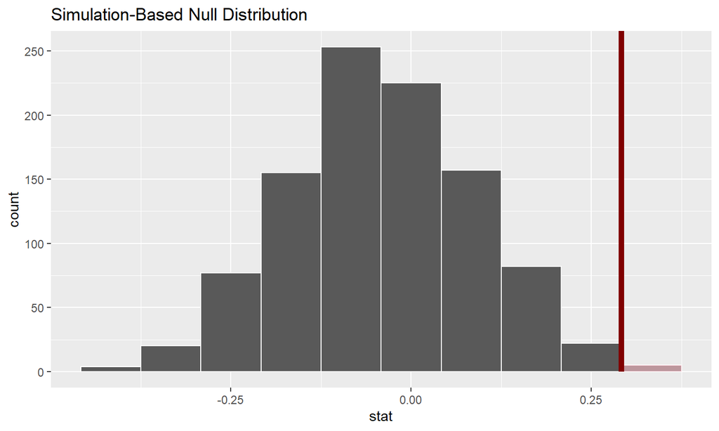

## Comparison with Traditional \(\chi^2\) Test

```r
chisq_test(promotions, decision ~ gender)
```

```
## # A tibble: 1 x 3
##   statistic chisq_df p_value
##       <dbl>    <int>   <dbl>
## 1      3.80        1  0.0513
```

## Regression, Classification, Machine Learning & Modeling

## Mixup in the Use of the Terms

- Regression is *at the same time*
  - The principal **statistical model** of all
  - The principal **machine learning tool** of all

## Uses of Modeling – Explanation

- Describe and quantify relationships
  - Between outcome variable \(y\) and set of explanatory variables \(x\)
  - Summarize relationships
  - Identify causal relationships
  - Meeting assumptions important

## Uses of Modeling – Prediction

- Predict new values for an outcome variable \(y\) based on information in predictor variables \(x\)
  - Niceties of relations and assumptions not so important
  - Prediction accuracy defines a successful model
  - Especially on data not used to train the model

## Machine Learning x Statistics

- Explanatory models – Statistics
- Prediction models – Machine Learning

## Two Flavors of Machine Learning

- **Supervised** – outcome variable exists and predictor variables used to determine changes in outcome variable
- **Unsupervised** – **no** outcome variable; look for structure of predictor variables within cases

## Regression

## Data

- Teaching evaluations at University of Texas, Austin
  - Home of the Longhorns - “Hook ’em Horns!”
- 463 Courses evaluated
- To what extent is teaching score related to age and to gender of the profs

## Load Data

```r
tx_evals <- readRDS(here("ut_austin_evals.rds"))
glimpse(tx_evals)
```

```
## Rows: 463
## Columns: 5
## $ ID      <int> 1, 2, 3, 4, 5, 6, 7, 8, 9, 10, 11, 12, 13, 14, 15, 16, 17, ...
## $ prof_ID <int> 1, 1, 1, 1, 2, 2, 2, 3, 3, 4, 4, 4, 4, 4, 4, 4, 4, 5, 5, 5,...
## $ score   <dbl> 4.7, 4.1, 3.9, 4.8, 4.6, 4.3, 2.8, 4.1, 3.4, 4.5, 3.8, 4.5,...
## $ age     <int> 36, 36, 36, 36, 59, 59, 59, 51, 51, 40, 40, 40, 40, 40, 40,...
## $ gender  <fct> female, female, female, female, male, male, male, male, mal...
```

## Model Data

- \(y\) - Teacher’s teaching score
- \(x_1\) - Teacher’s age (`age`)
- \(x_2\) - Teacher’s gender (`gender`)

## Some of the Data

```r
tx_evals %>% sample_n(size = 6)
```

```
## # A tibble: 6 x 5
##      ID prof_ID score   age gender
##   <int>   <int> <dbl> <int> <fct>
## 1   255      49   3.5    52 male
## 2   283      53   3.8    34 female
## 3   347      70   4.6    43 male
## 4   376      76   2.7    43 female
## 5   208      23   4.4    62 male
## 6   161      29   3.6    70 male
```

## Look at Gender (factor) Variable

```r
summarytools::freq(tx_evals$gender)
```

```
## Frequencies
## tx_evals$gender
## Type: Factor
##
##                Freq   % Valid   % Valid Cum.   % Total   % Total Cum.
## ------------ ------ --------- -------------- --------- --------------
##       female    195     42.12          42.12     42.12          42.12
##         male    268     57.88         100.00     57.88         100.00
##         <NA>      0                               0.00         100.00
##        Total    463    100.00         100.00    100.00         100.00
```

## Look at Numeric Variables (`score`, `age`)

```r
tx_evals %>%
  select(age, score) %>%
  summarytools::descr(stat = "common")
```

```
## Descriptive Statistics
## tx_evals
## N: 463
##
##                      age    score
## --------------- -------- --------
##            Mean    48.37     4.17
##         Std.Dev     9.80     0.54
##             Min    29.00     2.30
##          Median    48.00     4.30
##             Max    73.00     5.00
##         N.Valid   463.00   463.00
##       Pct.Valid   100.00   100.00
```

## Are Age and Score Correlated?

```r
tx_evals %>%
  get_correlation(formula = score ~ age)
```

```
## # A tibble: 1 x 1
##      cor
##    <dbl>
## 1 -0.107
```

## Plot Evaluation Variables

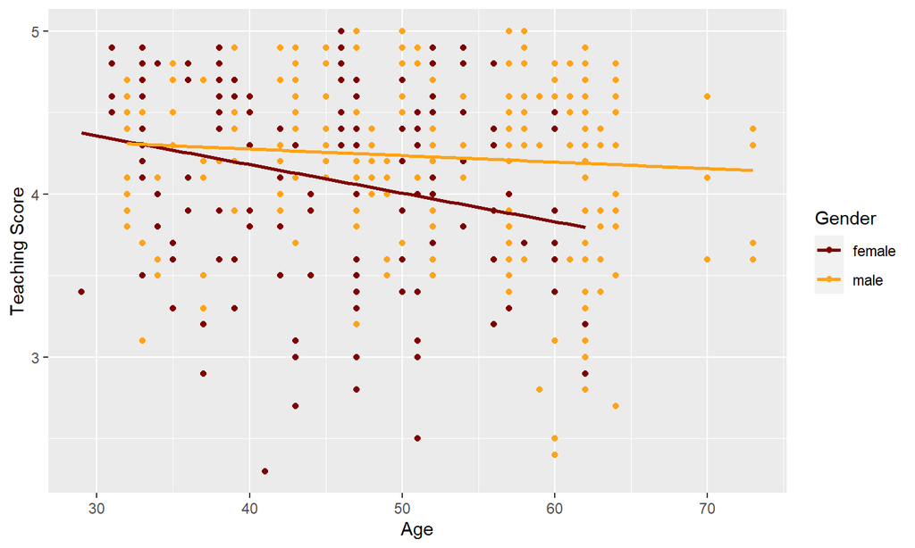

```r
gg_eval_vars <- ggplot(tx_evals, aes(x = age, y = score, color = gender)) +
  geom_point() +
   scale_colour_manual(values = c(new_uchic[1], new_uchic[3])) +
  labs(x = "Age", y = "Teaching Score", color = "Gender") +
  geom_smooth(method = "lm", se = FALSE)
```

## Basic Regression Model

- Also called “parallel slopes” model
- Forces two slopes to be parallel
  - assigns only 1 slope to age

```r
fit_base <- lm(score ~ age + gender, data = tx_evals)
get_regression_table(fit_base)
```

```
## # A tibble: 3 x 7
##   term       estimate std_error statistic p_value lower_ci upper_ci
##   <chr>         <dbl>     <dbl>     <dbl>   <dbl>    <dbl>    <dbl>
## 1 intercept     4.48      0.125     35.8    0        4.24     4.73
## 2 age          -0.009     0.003     -3.28   0.001   -0.014   -0.003
## 3 gendermale    0.191     0.052      3.63   0        0.087    0.294
```

## Interpretation of Basic Model

- Intercept for women (base category) is 4.484
- Intercept for men is intercept + gendermale = 4.484 + 0.191 = 4.675
  - gendermale is an offset from the women’s score level
- Slope for both females and males is -0.009
  - Everyone loses 0.009 from their score for every year they age
    - Ageism: For shame!

## An Interaction Regression Model

- Assumes values of `age` and `gender` depend on each other
- Therefore men and women can have different slopes for `age`
- Seen in different slopes in graph
- Instead of `+`, use a `*` to show an interaction model
- Regression lines in graph reflect interactions
  - Different slopes

## Interaction Regression Table

```r
fit_int <- lm(score ~ age * gender, data = tx_evals)
get_regression_table(fit_int)
```

```
## # A tibble: 4 x 7
##   term           estimate std_error statistic p_value lower_ci upper_ci
##   <chr>             <dbl>     <dbl>     <dbl>   <dbl>    <dbl>    <dbl>
## 1 intercept         4.88      0.205     23.8    0        4.48     5.29
## 2 age              -0.018     0.004     -3.92   0       -0.026   -0.009
## 3 gendermale       -0.446     0.265     -1.68   0.094   -0.968    0.076
## 4 age:gendermale    0.014     0.006      2.45   0.015    0.003    0.024
```

## Interpretation of Model – Females

- Base category for categorical variable `gender` is *female*
- Intercept: *only for females* Base score is 4.883
- Slope (estimate for age): Again, only for females
  - For each year older, women lose 0.018 score

## Model Again

```r
get_regression_table(fit_int)
```

```
## # A tibble: 4 x 7
##   term           estimate std_error statistic p_value lower_ci upper_ci
##   <chr>             <dbl>     <dbl>     <dbl>   <dbl>    <dbl>    <dbl>
## 1 intercept         4.88      0.205     23.8    0        4.48     5.29
## 2 age              -0.018     0.004     -3.92   0       -0.026   -0.009
## 3 gendermale       -0.446     0.265     -1.68   0.094   -0.968    0.076
## 4 age:gendermale    0.014     0.006      2.45   0.015    0.003    0.024
```

## Interpretation of Model – Males

- Estimate for `gendermale` (-0.446) is **offset** of intercept relative to female profs
- Intercept for male instructors = 4.883 - 0.446 = 4.437
- `age:gendermale` term is again offset of slope of women
- Slope for males = -0.018 + 0.014 = -0.004

## A Larger Regression Model

## Data – Credit Model from ISLR

- James, Witten, Hastie & Tibshirani, **Introduction to Statistical Learning with Applications in R**, 2017.
- Measures the debt someone should be carrying based on predictor variables
  - Credit Limit
  - Income
  - Age
  - Credit Rating
- All variables numeric

## Load `credit`

```r
credit <- readRDS(here("credit.rds"))
glimpse(credit)
```

```
## Rows: 400
## Columns: 6
## $ ID            <int> 1, 2, 3, 4, 5, 6, 7, 8, 9, 10, 11, 12, 13, 14, 15, 16...
## $ debt          <int> 333, 903, 580, 964, 331, 1151, 203, 872, 279, 1350, 1...
## $ credit_limit  <int> 3606, 6645, 7075, 9504, 4897, 8047, 3388, 7114, 3300,...
## $ income        <dbl> 14.891, 106.025, 104.593, 148.924, 55.882, 80.180, 20...
## $ credit_rating <int> 283, 483, 514, 681, 357, 569, 259, 512, 266, 491, 589...
## $ age           <int> 34, 82, 71, 36, 68, 77, 37, 87, 66, 41, 30, 64, 57, 4...
```

## Random Sample of Cases

```r
credit %>% select(-ID) %>% sample_n(size = 6)
```

```
## # A tibble: 6 x 5
##    debt credit_limit income credit_rating   age
##   <int>        <int>  <dbl>         <int> <int>
## 1  1549         6207   33.4           451    44
## 2   216         3615   23.8           263    70
## 3   802         5384   23.9           398    73
## 4   602         4160   12             320    28
## 5   162         3449   27.4           288    40
## 6  1216         4391   10.8           358    37
```

## Exploratory Data

```r
credit %>% select(-ID) %>%
  summarytools::descr(stat = "common")
```

```
## Descriptive Statistics
## credit
## N: 400
##
##                      age   credit_limit   credit_rating      debt   income
## --------------- -------- -------------- --------------- --------- --------
##            Mean    55.67        4735.60          354.94    520.02    45.22
##         Std.Dev    17.25        2308.20          154.72    459.76    35.24
##             Min    23.00         855.00           93.00      0.00    10.35
##          Median    56.00        4622.50          344.00    459.50    33.12
##             Max    98.00       13913.00          982.00   1999.00   186.63
##         N.Valid   400.00         400.00          400.00    400.00   400.00
##       Pct.Valid   100.00         100.00          100.00    100.00   100.00
```

## Correlations

```r
credit %>%
  select(-ID) %>% cor()
```

```
##                      debt credit_limit    income credit_rating         age
## debt          1.000000000    0.8616973 0.4636565     0.8636252 0.001835119
## credit_limit  0.861697267    1.0000000 0.7920883     0.9968797 0.100887922
## income        0.463656457    0.7920883 1.0000000     0.7913776 0.175338403
## credit_rating 0.863625161    0.9968797 0.7913776     1.0000000 0.103164996
## age           0.001835119    0.1008879 0.1753384     0.1031650 1.000000000
```

- High degree of collinearity among some explanatory variables
  - Indicates redundant information and violates assumptions
  - Will remove credit rating to remove 0.997 correlation

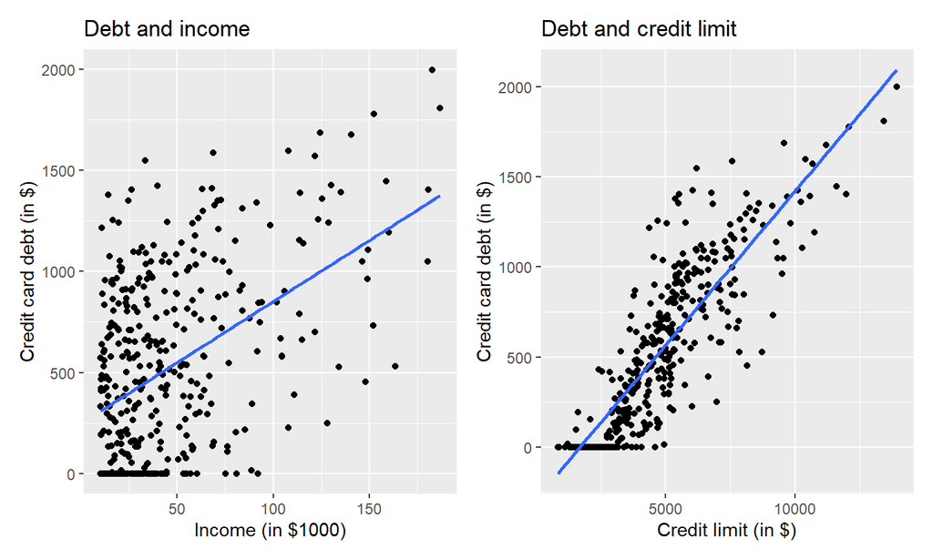

## Fit a Model

- With all numeric variables we can fit a basic model

```r
fit_debt <- lm(debt ~ credit_limit + income + age, data = credit)
get_regression_table(fit_debt)
```

```
## # A tibble: 4 x 7
##   term         estimate std_error statistic p_value lower_ci upper_ci
##   <chr>           <dbl>     <dbl>     <dbl>   <dbl>    <dbl>    <dbl>
## 1 intercept    -342.       32.6      -10.5    0     -406.    -278.
## 2 credit_limit    0.264     0.006     44.9    0        0.252    0.275
## 3 income         -7.56      0.389    -19.4    0       -8.33    -6.80
## 4 age            -0.802     0.488     -1.64   0.101   -1.76     0.157
```

## Fitted Values and Residuals

```r
get_regression_points(fit_debt)
```

```
## # A tibble: 400 x 7
##       ID  debt credit_limit income   age debt_hat residual
##    <int> <int>        <int>  <dbl> <int>    <dbl>    <dbl>
##  1     1   333         3606   14.9    34     469.   -136.
##  2     2   903         6645  106.     82     543.    360.
##  3     3   580         7075  105.     71     676.    -95.6
##  4     4   964         9504  149.     36    1009.    -45.0
##  5     5   331         4897   55.9    68     472.   -141.
##  6     6  1151         8047   80.2    77    1112.     39.2
##  7     7   203         3388   21.0    37     363.   -160.
##  8     8   872         7114   71.4    87     924.    -52.0
##  9     9   279         3300   15.1    66     361.    -81.7
## 10    10  1350         6819   71.1    41     886.    464.
## # ... with 390 more rows
```